# Comunicação célula-célula em transcriptômica espacial com CellChat e PathwaySpace

Flávio Gabriel Carazza-Kessler

# 1 Visão geral

Nesta vinheta, usaremos o objeto Seurat processado na etapa anterior do curso para inferir e visualizar comunicação célula-célula em dados de transcriptômica espacial. O fluxo reúne duas abordagens complementares:

1. o **CellChat** estima interações ligante–receptor entre os clusters dos spots (Jin et al. 2021; Jin, Plikus, and Nie 2025); e
2. o **RGraphSpace/PathwaySpace** representa essas interações entre spots vizinhos e projeta o sinal no tecido (Sysbiolab Team 2026; Tercan et al. 2025; Ellrott et al. 2025).

O objeto de entrada é obrigatoriamente `data/brain.RDS`, gerado pela vinheta de controle de qualidade, pré-processamento e clusterização. Embora ele contenha as seções anterior e posterior do conjunto `stxBrain`, manteremos somente a região `anterior` logo após o carregamento. Assim, todos os cálculos, resultados e gráficos desta vinheta serão produzidos apenas com essa região. O objeto também contém a expressão normalizada pelo `SCTransform()` e os clusters do Seurat (Hao et al. 2024).

Ao final, a tabela de comunicações projetadas entre spots será salva como:

```
resultados/spot-spot_commu_anterior.rds
```

> **Como interpretar o resultado:** o CellChat estima a comunicação no nível dos grupos, que nesta análise são os clusters do Seurat. A tabela spot–spot é uma projeção dessas estimativas sobre pares de spots espacialmente próximos e compatíveis com os clusters de origem e destino. Portanto, ela não representa uma inferência independente do CellChat para cada par individual de spots.

# 2 Preparar o ambiente

## 2.1 Estrutura das pastas

Antes de executar o código, defina o diretório de trabalho como a pasta `vinhetas/`. No RStudio, use **Session > Set Working Directory > To Source File Location**.

```
Curso_ST/
|-- data/
|   `-- brain.RDS
|-- imagens/
|-- resultados/
`-- vinhetas/
    |-- CellChat_Comunicacao_Celular_PathwaySpace.Rmd
    `-- CellChat_Comunicacao_Celular_PathwaySpace.html
```

```r
diretorio_vinhetas <- getwd()
diretorio_curso <- dirname(diretorio_vinhetas)
diretorio_dados <- file.path(diretorio_curso, "data")
diretorio_imagens <- file.path(diretorio_curso, "imagens")
diretorio_resultados <- file.path(diretorio_curso, "resultados")

dir.create(diretorio_imagens, showWarnings = FALSE, recursive = TRUE)
dir.create(diretorio_resultados, showWarnings = FALSE, recursive = TRUE)
```

## 2.2 Conferir os pacotes necessários

A instalação de todos os pacotes e de suas dependências está centralizada em `Configuracao_do_ambiente_RStudio.Rmd`. Execute a primeira vinheta, reinicie a sessão do R e então use o bloco abaixo apenas para confirmar que o ambiente está pronto.

```r
pacotes_cellchat <- c(
  "CellChat", "RGraphSpace", "PathwaySpace", "Seurat", "SeuratObject",
  "dplyr", "tibble", "tidyr", "ggplot2", "RANN", "future"
)

pacotes_ausentes <- pacotes_cellchat[
  !vapply(pacotes_cellchat, requireNamespace, logical(1), quietly = TRUE)
]

if (length(pacotes_ausentes) > 0) {
  stop(
    "Execute primeiro Configuracao_do_ambiente_RStudio.Rmd. ",
    "Pacotes ausentes: ",
    paste(pacotes_ausentes, collapse = ", ")
  )
}
```

## 2.3 Carregar os pacotes

Carregamos os pacotes usados na inferência, na manipulação dos dados e nas visualizações. Esta vinheta adota o Seurat 5.5.1 como referência.

```r
library("CellChat")
library("RGraphSpace")
library("PathwaySpace")
library("Seurat")
library("SeuratObject")
library("dplyr")
library("tibble")
library("tidyr")
library("ggplot2")

options(stringsAsFactors = FALSE)

packageVersion("Seurat")
```

```
#> [1] '5.5.1'
```

# 3 Carregar o objeto espacial produzido anteriormente

Após carregar o objeto completo, o `subset()` descarta todos os spots da região posterior. A imagem espacial correspondente também é removida do objeto, mantendo apenas a seção `anterior1` para as etapas seguintes.

```r
brain <- readRDS(file.path(diretorio_dados, "brain.RDS"))
brain <- subset(brain, subset = region == "anterior")

DefaultAssay(brain) <- "SCT"
Idents(brain) <- "seurat_clusters"

if (length(Images(brain)) != 1L) {
  stop("O subset da região anterior deve manter exatamente uma imagem espacial.")
}

nome_imagem <- Images(brain)[1]

brain
```

```
#> An object of class Seurat
#> 49293 features across 2696 samples within 2 assays
#> Active assay: SCT (18240 features, 3000 variable features)
#>  3 layers present: counts, data, scale.data
#>  1 other assay present: Spatial
#>  3 dimensional reductions calculated: pca, umap, tsne
#>  1 spatial field of view present: anterior1
```

```r
table(brain$region)
```

```
#>
#> anterior
#>     2696
```

O resultado esperado é um objeto com 2.696 spots e uma única imagem, denominada `anterior1`.

# 4 Preparar as entradas do CellChat

O CellChat requer quatro componentes principais para dados espaciais:

- `data.input`: matriz normalizada de genes por spots;
- `meta`: rótulos dos clusters e das amostras;
- `spatial.locs`: coordenadas espaciais em resolução completa; e
- `spatial.factors`: fatores usados para converter pixels em micrômetros.

## 4.1 Expressão normalizada e metadados

A camada normalizada do ensaio `SCT` fornece a expressão usada pelo CellChat. Os metadados associam cada spot ao seu cluster do Seurat e à única amostra espacial mantida.

```r
data.input <- LayerData(brain, assay = "SCT", layer = "data")
spots_anterior <- Cells(brain[[nome_imagem]])
data.input <- data.input[, spots_anterior, drop = FALSE]

metadados_brain <- brain[[]]

meta <- data.frame(
  labels = paste0("cluster_",
    metadados_brain[colnames(data.input), "seurat_clusters"]),
  samples = nome_imagem,
  row.names = colnames(data.input)
)

meta$labels <- factor(meta$labels)
meta$samples <- factor(meta$samples, levels = nome_imagem)

table(meta$labels, meta$samples)
```

```
#>
#>              anterior1
#>   cluster_0        223
#>   cluster_1        659
#>   cluster_10       220
#>   cluster_11        51
#>   cluster_12         1
#>   cluster_13         2
#>   cluster_14       142
#>   cluster_15       125
#>   cluster_16       121
#>   cluster_19        84
#>   cluster_2        554
#>   cluster_20        14
#>   cluster_21        34
#>   cluster_3         51
#>   cluster_4          2
#>   cluster_6        107
#>   cluster_7        306
```

## 4.2 Coordenadas e fatores espaciais

No Seurat 5.5.1, `GetTissueCoordinates()` retorna as posições não escaladas do `VisiumV2` nas colunas `x` e `y`. Depois de alinhar os spots às colunas da matriz de expressão, estimamos o fator que converte pixels em micrômetros. Para o Visium, adotamos 100 µm entre centros de spots adjacentes e 55 µm como diâmetro teórico do spot.

```r
spatial.locs <- GetTissueCoordinates(
  brain, image = nome_imagem, scale = NULL)
spatial.locs <- as.data.frame(spatial.locs[, c("x", "y"), drop = FALSE])
spatial.locs <- spatial.locs[colnames(data.input), , drop = FALSE]

spot.size <- 55
distancia_centros <- 100
distancias <- computeCellDistance(coordinates = spatial.locs)
menor_distancia <- min(distancias[distancias > 0])

spatial.factors <- data.frame(
  ratio = distancia_centros / menor_distancia,
  tol = spot.size / 2,
  row.names = nome_imagem
)

spatial.factors
```

```
#>              ratio  tol
#> anterior1 0.729927 27.5
```

```r
head(spatial.locs)
```

```
#>                         x    y
#> AAACAAGTATCTCCCA-1_1 8501 7475
#> AAACACCAATAACTGC-1_1 2788 8553
#> AAACAGAGCGACTCCT-1_1 7950 3164
#> AAACAGCTTTCAGAAG-1_1 2099 6637
#> AAACAGGGTCTATATT-1_1 2375 7116
#> AAACATGGTGAGAGGA-1_1 1480 8913
```

## 4.3 Criar o objeto CellChat

Com expressão, rótulos, coordenadas e escala na mesma ordem, construímos o objeto espacial que será usado na inferência.

```r
cellchat <- createCellChat(
  object = data.input, meta = meta, group.by = "labels",
  datatype = "spatial", coordinates = spatial.locs,
  spatial.factors = spatial.factors
)
```

```
#> [1] "Create a CellChat object from a data matrix"
#> Create a CellChat object from spatial transcriptomics data...
#> Set cell identities for the new CellChat object
#> The cell groups used for CellChat analysis are  cluster_0, cluster_1, cluster_10, cluster_11, cluster_12, cluster_13, cluster_14, cluster_15, cluster_16, cluster_19, cluster_2, cluster_20, cluster_21, cluster_3, cluster_4, cluster_6, cluster_7
```

```r
cellchat
```

```
#> An object of class CellChat created from a single dataset
#>  18240 genes.
#>  2696 cells.
#> CellChat analysis of spatial data! The input spatial locations are
#>                      x_cent y_cent
#> AAACAAGTATCTCCCA-1_1   8501   7475
#> AAACACCAATAACTGC-1_1   2788   8553
#> AAACAGAGCGACTCCT-1_1   7950   3164
#> AAACAGCTTTCAGAAG-1_1   2099   6637
#> AAACAGGGTCTATATT-1_1   2375   7116
#> AAACATGGTGAGAGGA-1_1   1480   8913
```

# 5 Definir a base de interações ligante–receptor

Como o conjunto `stxBrain` é de camundongo, usaremos `CellChatDB.mouse`. Para manter o tempo de execução adequado à atividade didática, a análise será restrita à categoria **Secreted Signaling**.

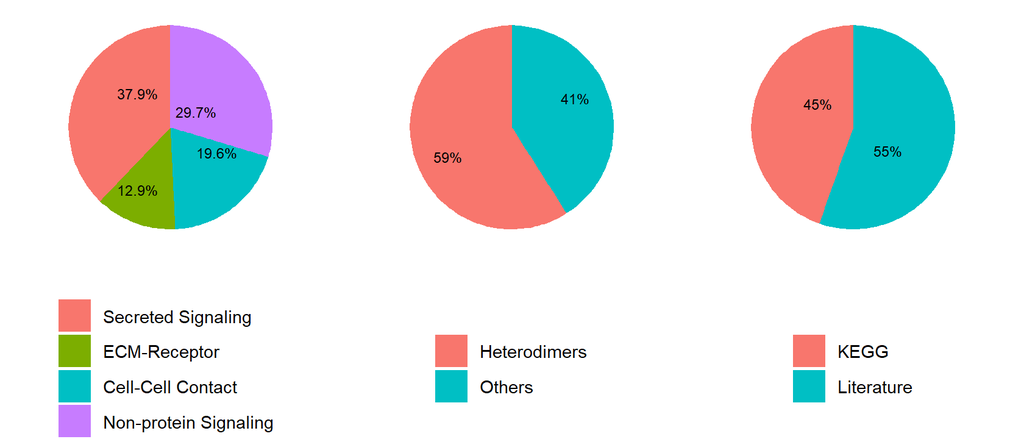

```r
CellChatDB <- CellChatDB.mouse
showDatabaseCategory(CellChatDB)
```

```r
CellChatDB.use <- subsetDB(CellChatDB,
  search = "Secreted Signaling", key = "annotation")

cellchat@DB <- CellChatDB.use
```

# 6 Pré-processar os dados de expressão

O CellChat mantém os genes presentes na base selecionada e identifica genes e interações com expressão aumentada. A função `plan()` com opção `multisession` permite distribuir essa etapa em até quatro processos do R (*cores*).

```r
cellchat <- subsetData(cellchat)

future::plan("multisession", workers = 4)

cellchat <- identifyOverExpressedGenes(cellchat)
cellchat <- identifyOverExpressedInteractions(cellchat, variable.both = FALSE)
```

```
#> The number of highly variable ligand-receptor pairs used for signaling inference is 843
```

# 7 Inferir a comunicação entre os clusters

Nesta etapa, as interações e comunicações dependentes de contato foram restringidas a 100 µm, aproximadamente a distância entre os centros de spots adjacentes no Visium. Esse corte ajuda a acelerar a análise.

Para demonstração de aula, `nboot` foi limitado a 10 para calcular mais rápido. `nboot` é número de testes de permutação utilizado para calcular os p-valores.

**Cuidado:*** Etapa mais custosa da vinheta, a execução pode levar vários minutos.

```r
cellchat <- computeCommunProb(
  cellchat, type = "triMean", distance.use = TRUE,
  interaction.range = 100, scale.distance = 0.01,
  contact.range = 100, contact.dependent = TRUE,
  contact.knn.k = 6, nboot = 10
)
```

```
#> triMean is used for calculating the average gene expression per cell group.
#> [1] ">>> Run CellChat on spatial transcriptomics data using distances as constraints of the computed communication probability <<< [2026-10-29 15:10:59.386074]"
#> Molecules of the input L-R pairs are diffusible. Run CellChat in a diffusion manner based on the `interaction.range`.
#> [1] ">>> CellChat inference is done. Parameter values are stored in `object@options$parameter` <<< [2026-10-29 15:18:09.625556]"
```

```r
cellchat <- filterCommunication(cellchat, min.cells = 10)
```

```
#> The cell-cell communication related with the following cell groups are excluded due to the few number of cells:  cluster_12, cluster_13, cluster_4 !     3.4% interactions are removed!
```

Extraímos somente as interações com valor de *p* inferior a 0,05. A conversão dos grupos para texto facilitará as junções com as tabelas de spots.

```r
df.net <- subsetCommunication(cellchat, thresh = 0.05)

df.net <- df.net %>%
  mutate(source = as.character(source), target = as.character(target))

head(df.net)
```

```
#>       source     target ligand  receptor         prob pval    interaction_name       interaction_name_2
#> 1 cluster_15 cluster_10  Tgfb2 TGFbR1_R2 0.0001552777    0 TGFB2_TGFBR1_TGFBR2 Tgfb2  - (Tgfbr1+Tgfbr2)
#> 2 cluster_15 cluster_15  Tgfb2 TGFbR1_R2 0.0008158957    0 TGFB2_TGFBR1_TGFBR2 Tgfb2  - (Tgfbr1+Tgfbr2)
#> 3 cluster_16 cluster_16  Tgfb2 TGFbR1_R2 0.0012826438    0 TGFB2_TGFBR1_TGFBR2 Tgfb2  - (Tgfbr1+Tgfbr2)
#> 4 cluster_19 cluster_16  Tgfb2 TGFbR1_R2 0.0002097974    0 TGFB2_TGFBR1_TGFBR2 Tgfb2  - (Tgfbr1+Tgfbr2)
#> 5 cluster_21 cluster_21  Tgfb2 TGFbR1_R2 0.0039567110    0 TGFB2_TGFBR1_TGFBR2 Tgfb2  - (Tgfbr1+Tgfbr2)
#> 6  cluster_3  cluster_3  Tgfb2 TGFbR1_R2 0.0004540627    0 TGFB2_TGFBR1_TGFBR2 Tgfb2  - (Tgfbr1+Tgfbr2)
#>   pathway_name         annotation       evidence
#> 1         TGFb Secreted Signaling KEGG: mmu04350
#> 2         TGFb Secreted Signaling KEGG: mmu04350
#> 3         TGFb Secreted Signaling KEGG: mmu04350
#> 4         TGFb Secreted Signaling KEGG: mmu04350
#> 5         TGFb Secreted Signaling KEGG: mmu04350
#> 6         TGFb Secreted Signaling KEGG: mmu04350
```

# 8 Projetar as comunicações para pares de spots

Agora identificaremos os pares de spots da região anterior separados por até 100 µm. Depois, cada par receberá os clusters de origem e destino e será combinado às interações inferidas pelo CellChat.

```r
interaction.range <- 100

coordenadas_um <- spatial.locs * spatial.factors[nome_imagem, "ratio"]
matriz_distancias <- as.matrix(dist(coordenadas_um))
diag(matriz_distancias) <- Inf

indices <- which(matriz_distancias <= interaction.range, arr.ind = TRUE)

spot.pairs <- tibble(
  source_spot = rownames(matriz_distancias)[indices[, 1]],
  target_spot = colnames(matriz_distancias)[indices[, 2]],
  distance_um = matriz_distancias[indices],
  sample = nome_imagem
)

spot.groups <- tibble(spot = rownames(cellchat@meta),
  group = as.character(cellchat@idents))

spot.pairs <- spot.pairs %>%
  left_join(spot.groups, by = c("source_spot" = "spot")) %>%
  rename(source = group) %>%
  left_join(spot.groups, by = c("target_spot" = "spot")) %>%
  rename(target = group)

head(spot.pairs)
```

```
#> # A tibble: 6 × 6
#>   source_spot          target_spot          distance_um sample    source     target
#>   <chr>                <chr>                      <dbl> <chr>     <chr>      <chr>
#> 1 ACTAGTTGCGATCGTC-1_1 AAACAAGTATCTCCCA-1_1       100   anterior1 cluster_6  cluster_0
#> 2 GGAACCTTGACTCTGC-1_1 AAACACCAATAACTGC-1_1       100.0 anterior1 cluster_10 cluster_10
#> 3 TTGCGTGAACGCTTAG-1_1 AAACAGAGCGACTCCT-1_1       100   anterior1 cluster_7  cluster_7
#> 4 CCGCCTTGCGATGTCG-1_1 AAACAGCTTTCAGAAG-1_1       100   anterior1 cluster_15 cluster_15
#> 5 CGAACGGCCGGACAAC-1_1 AAACAGGGTCTATATT-1_1       100   anterior1 cluster_15 cluster_15
#> 6 TCACAAACCGAGGTAC-1_1 AAACATTTCCCGGATT-1_1       100   anterior1 cluster_16 cluster_16
```

As interações inferidas para cada par de clusters são então associadas aos pares de spots compatíveis. A tabela resultante é ordenada e salva para reutilização.

```r
spot.to.spot.communication <- spot.pairs %>%
  inner_join(df.net, by = c("source", "target")) %>%
  arrange(sample, source_spot, target_spot,
    pathway_name, interaction_name)

head(spot.to.spot.communication)
```

```
#> # A tibble: 6 × 15
#>   source_spot         target_spot distance_um sample source target ligand receptor   prob  pval interaction_name
#>   <chr>               <chr>             <dbl> <chr>  <chr>  <chr>  <chr>  <chr>     <dbl> <dbl> <fct>
#> 1 AAACAAGTATCTCCCA-1… ACTAGTTGCG…         100 anter… clust… clust… Fgf1   Fgfr1    0.0161     0 FGF1_FGFR1
#> 2 AAACAAGTATCTCCCA-1… ACTAGTTGCG…         100 anter… clust… clust… Fgf1   Fgfr2    0.0382     0 FGF1_FGFR2
#> 3 AAACAAGTATCTCCCA-1… ACTAGTTGCG…         100 anter… clust… clust… Fgf1   Fgfr3    0.0222     0 FGF1_FGFR3
#> 4 AAACAAGTATCTCCCA-1… ACTAGTTGCG…         100 anter… clust… clust… Gas6   Tyro3    0.0448     0 GAS6_TYRO3
#> 5 AAACAAGTATCTCCCA-1… ACTAGTTGCG…         100 anter… clust… clust… Mdk    Sdc4     0.0161     0 MDK_SDC4
#> 6 AAACAAGTATCTCCCA-1… ACTAGTTGCG…         100 anter… clust… clust… Mdk    Ptprz1   0.0345     0 MDK_PTPRZ1
#> # ℹ 4 more variables: interaction_name_2 <chr>, pathway_name <chr>, annotation <chr>, evidence <chr>
```

```r
saveRDS(
  spot.to.spot.communication,
  file = file.path(diretorio_resultados,
    "spot-spot_commu_anterior.rds")
)
```

# 9 Construir a rede espacial no RGraphSpace

O `GraphSpace` reúne as coordenadas, os metadados, a expressão normalizada e a imagem da seção anterior. As coordenadas em baixa resolução permitem sobrepor corretamente a rede à imagem do tecido.

```r
spots_visualizacao <- spots_anterior

coordenadas_gs <- GetTissueCoordinates(
  brain, image = nome_imagem, scale = "lowres"
)
coordenadas_gs <- coordenadas_gs[
  spots_visualizacao, c("x", "y"), drop = FALSE
]

metadados_gs <- brain[[]][spots_visualizacao, , drop = FALSE]
gs <- GraphSpace(cbind(coordenadas_gs, metadados_gs))
```

```
#> Converting input data to an 'igraph' object...
#> Validating the 'igraph' object...
#> Creating a 'GraphSpace' object...
```

```r
gs_fdata(gs) <- LayerData(
  brain, assay = "SCT", layer = "data"
)[, spots_visualizacao, drop = FALSE]
```

```
#> Feature matrix transposed: more node IDs found in columns than rows.
```

```r
gs_image(gs) <- GetImage(
  brain[[nome_imagem]], mode = "raster"
)

gs <- normalizeGraphSpace(gs)
```

```
#> Normalizing node coordinates to image space...
#> Flipping y-coordinates over image center...
```

Primeiro, conferimos a posição dos clusters sobre a imagem antes de acrescentar as relações de proximidade.

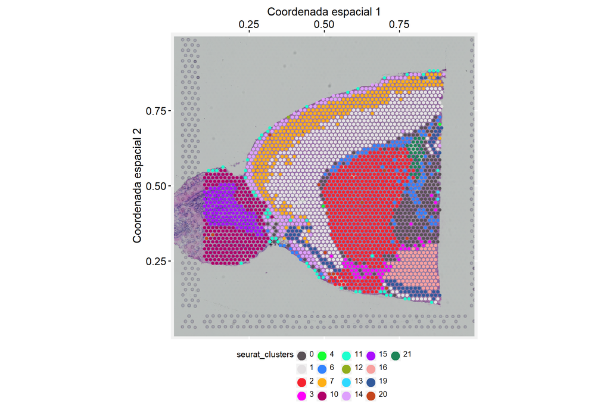

```r
spatial_theme <- theme_gspace_coords(
  theme = "th3", is_norm = TRUE,
  xlab = "Coordenada espacial 1", ylab = "Coordenada espacial 2"
)

cpal1 <- DiscretePalette(nlevels(gs$seurat_clusters), "polychrome")

ggplot(gs) +
  annotation_gspace_image(gs) +
  geom_nodespace(mapping = aes(colour = seurat_clusters),
    size = 1, pch = 19) +
  scale_colour_manual(values = cpal1) +
  theme_gspace_legend(discrete_colour = TRUE) +
  spatial_theme
```

## 9.1 Adicionar as relações de proximidade

A função abaixo conecta cada spot aos seis vizinhos mais próximos, respeitando o arranjo hexagonal esperado da lâmina Visium. Spots das bordas podem ter menos vizinhos.

```r
proximityNetwork <- function(gs, nnei = 6) {
  nodes <- gs@nodes

  vizinhos <- RANN::nn2(nodes[, c("x", "y")],
    nodes[, c("x", "y")], k = nnei + 1)

  distancias <- as.data.frame(vizinhos$nn.dists[, 2:(nnei + 1)])
  indices <- as.data.frame(vizinhos$nn.idx[, 2:(nnei + 1)])

  distancia_tipica <- 1 / mean(1 / distancias$V1)
  manter <- distancias
  manter[, 1] <- TRUE
  manter[, 2:ncol(manter)] <-
    distancias[, 2:ncol(distancias)] >= 0.95 * distancia_tipica &
    distancias[, 2:ncol(distancias)] <= 1.05 * distancia_tipica

  matriz_arestas <- manter * indices
  matriz_arestas$from <- row.names(matriz_arestas)

  arestas <- matriz_arestas %>%
    pivot_longer(cols = -from, names_to = "vizinho", values_to = "to") %>%
    filter(to != 0) %>%
    transmute(from = as.numeric(from), to = as.numeric(to),
      v1 = pmin(from, to), v2 = pmax(from, to)) %>%
    distinct(v1, v2) %>%
    transmute(from = nodes$name[v1], to = nodes$name[v2])

  gs_add_edges(gs) <- arestas
  gs
}
```

Antes de criar as arestas, ampliamos uma área central para observar apenas os spots. Essa visualização servirá de comparação para a rede construída no bloco seguinte.

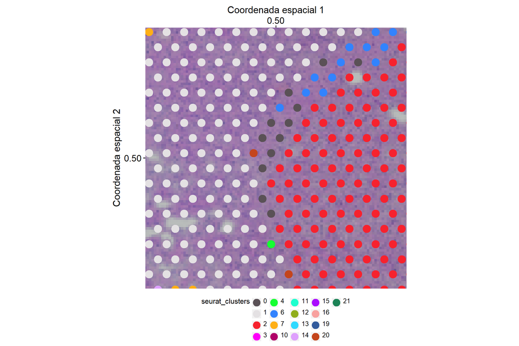

```r
ggplot(gs) +
  annotation_gspace_image(gs) +
  geom_edgespace() +
  geom_nodespace(mapping = aes(colour = seurat_clusters),
    size = 3, pch = 19) +
  scale_colour_manual(values = cpal1) +
  theme_gspace_legend(discrete_colour = TRUE) +
  spatial_theme +
  coord_cartesian(xlim = c(0.4, 0.6), ylim = c(0.4, 0.6))
```

Agora aplicamos `proximityNetwork()` e repetimos o recorte. As linhas mostram quais spots serão considerados vizinhos na projeção das comunicações.

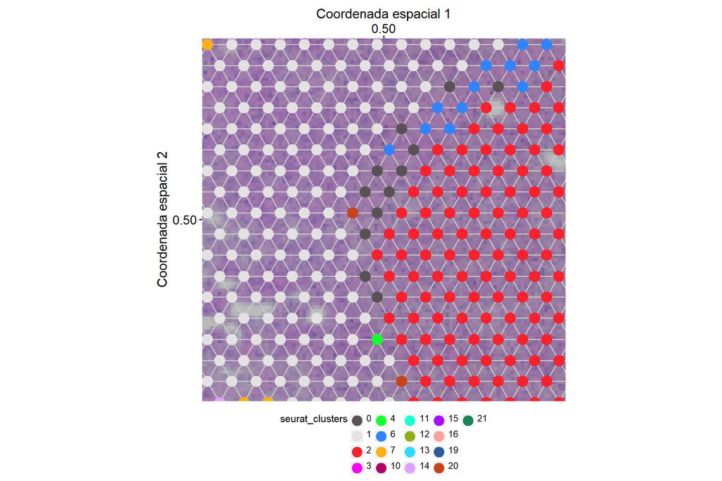

```r
gs <- proximityNetwork(gs)

ggplot(gs) +
  annotation_gspace_image(gs) +
  geom_edgespace() +
  geom_nodespace(mapping = aes(colour = seurat_clusters),
    size = 3, pch = 19) +
  scale_colour_manual(values = cpal1) +
  theme_gspace_legend(discrete_colour = TRUE) +
  spatial_theme +
  coord_cartesian(xlim = c(0.4, 0.6), ylim = c(0.4, 0.6))
```

# 10 Associar as comunicações às arestas de proximidade

As arestas do `GraphSpace` são não direcionadas, mas a comunicação ligante–receptor possui uma origem e um destino. Por isso, criaremos as duas orientações de cada aresta antes de associá-las às comunicações do CellChat.

```r
arestas <- gs@edges %>% select(name1, name2)

arestas_direcionadas <- bind_rows(
  arestas,
  arestas %>% transmute(name1 = name2, name2 = name1)
) %>%
  distinct()

spotCom_dt <- arestas_direcionadas %>%
  inner_join(
    spot.to.spot.communication %>% filter(sample == nome_imagem),
    by = c("name1" = "source_spot", "name2" = "target_spot")
  )

spotCom_dt$arrowType <- 1

interacoes_disponiveis <- spotCom_dt %>%
  select(ligand, receptor, interaction_name) %>%
  filter(!is.na(ligand), !is.na(receptor)) %>%
  distinct()

head(interacoes_disponiveis)
```

```
#>   ligand receptor interaction_name
#> 1   Fgf1    Fgfr1       FGF1_FGFR1
#> 2   Fgf1    Fgfr2       FGF1_FGFR2
#> 3   Fgf1    Fgfr3       FGF1_FGFR3
#> 4   Gas6    Tyro3       GAS6_TYRO3
#> 5    Mdk     Sdc4         MDK_SDC4
#> 6    Mdk   Ptprz1       MDK_PTPRZ1
```

# 11 Projetar uma interação com PathwaySpace

A função `communication_pathwayspace()` mantém os spots envolvidos em uma interação, constrói o objeto `PathwaySpace`, soma a expressão do ligante e do receptor e projeta esse sinal na rede. Nomes separados por sublinhado são tratados como complexos formados por mais de um gene.

```r
communication_pathwayspace <- function(gs, lig, recep, spotCom_dt) {
  comunicacoes <- spotCom_dt %>% filter(ligand == lig, receptor == recep)

  spots_selecionados <- unique(c(comunicacoes$name1, comunicacoes$name2))

  gs_selecionado <- gs_subset_nodes(gs, spots_selecionados)
  pspace_obj <- buildPathwaySpace(gs_selecionado)

  distancia_spots <- getNearestNode(pspace_obj)
  pdist <- mean(distancia_spots$dist)

  pspace_obj <- silhouetteMapping(pspace_obj, baseline = 0.1)

  resolver_features <- function(rotulo, features_disponiveis) {
    if (rotulo %in% features_disponiveis) {
      return(rotulo)
    }

    componentes <- strsplit(rotulo, "_", fixed = TRUE)[[1]]
    features_disponiveis[match(tolower(componentes),
      tolower(features_disponiveis))]
  }

  features_disponiveis <- colnames(pspace_obj@fdata)
  features_ligante <- resolver_features(lig, features_disponiveis)
  features_receptor <- resolver_features(recep, features_disponiveis)

  if (anyNA(c(features_ligante, features_receptor))) {
    stop("O ligante ou o receptor não foi encontrado nos dados de expressão.")
  }

  sinal_ligante <- rowSums(as.matrix(
    pspace_obj@fdata[, features_ligante, drop = FALSE]))
  sinal_receptor <- rowSums(as.matrix(
    pspace_obj@fdata[, features_receptor, drop = FALSE]))

  vertexSignal(pspace_obj) <- sinal_ligante + sinal_receptor

  pspace_obj <- circularProjection(
    pspace_obj, decay.fun = weibullDecay(decay = 0.5, pdist = pdist),
    aggregate.fun = signalAggregation("wmean"),
    k = gs_vcount(pspace_obj))

  pspace_obj
}
```

## 11.1 Visualizar um exemplo

Usaremos a primeira interação disponível na região anterior. Se preferir investigar um par específico, substitua `ligante_exemplo` e `receptor_exemplo` pelos símbolos desejados.

```r
if (nrow(interacoes_disponiveis) == 0) {
  stop("Nenhuma interação foi associada às arestas da região anterior.")
}

ligante_exemplo <- interacoes_disponiveis$ligand[1]
receptor_exemplo <- interacoes_disponiveis$receptor[1]

pspace_obj <- communication_pathwayspace(
  gs = gs, lig = ligante_exemplo, recep = receptor_exemplo,
  spotCom_dt = spotCom_dt)
```

```
#> Validating arguments...
#> Creating a 'PathwaySpace' object...
#> Validating arguments...
#> Mapping graph silhouette...
#> Mapping 'x' and 'y' coordinates...
#> Silhouette: 15.75% of the landscape area!
#> Validating arguments...
#> Using circular projection...
#> Mapping 'x' and 'y' coordinates...
#> Running signal convolution...
```

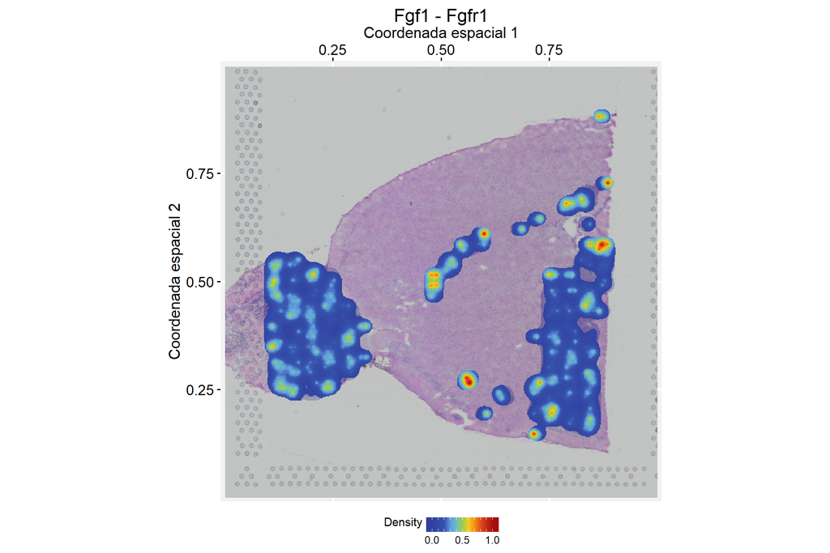

```r
grafico_exemplo <- ggplot(pspace_obj) +
  annotation_gspace_image(pspace_obj) +
  annotation_pspace_signal(pspace_obj, si.alpha = 0.25) +
  spatial_theme + labs(
    title = paste(ligante_exemplo, "-", receptor_exemplo))

grafico_exemplo
```